# Metaanalysis in R

SHUBHAM :437962

today

```r
install.packages("meta")
```

## Metaanalysis

*a statistical analysis that combines the results of multiple scientific studies.* ([Wikipedia](https://en.wikipedia.org/wiki/Meta-analysis))

Very important in e.g. medicine (where it’s relatively easy to use).

can serve various purposes:

1. Using data from several research, determining the “true” size of the association.
2. Calculating the average effect size from numerous research.
3. Identifying factors that impact the relationship
- study-related (e.g., effects of the author, the journal, the method, variable choice, etc.)
- linked to context (such as changes over time, sample characteristics, nation, etc.)
4. Determining publication biases (for instance, a meta-analysis of numerous papers that produced statistically significant results can come to the conclusion that there is insufficient evidence).

##Introduction:

In the realm of child development, the topic of toy preferences and their relation to gender has long been a subject of interest. The assignment at hand involves a meta-analysis study conducted by Todd et al. (2017) that delves into children’s toy preferences from a systematic review, meta-regression, and meta-analysis perspective. The dataset to be explored is sourced from this study and resides in the “metaanalysis_data.xlsx” file.

The primary focus of the study is to investigate the extent to which children’s choice of toys aligns with gender stereotypes, particularly the selection of stereotypically ‘boy-toys’ versus stereotypically ‘girl-toys.’ The dataset comprises crucial information such as mean playtimes (measured in seconds) for both boys and girls, sample sizes, and standard errors for each toy category. Beyond these metrics, the dataset encompasses details about the studies themselves, including the year of publication, indicators of quality, and contextual factors.

##Noteworthy factors included in the dataset are:

Neutral Toys: A binary variable indicating whether neutral toys were included or excluded in the study. Parent Presence: A categorical variable denoting the level of interaction a parent had during the study, ranging from minimal to full interaction. Setting: A categorical variable indicating the location of the study, whether conducted at home, in a laboratory, or at a nursery. Country: This variable encompasses the gender inequality index, a metric quantifying the level of gender egalitarianism in the country at the time of the study. The dataset’s quality is evaluated using the Newcastle-Ottawa Quality Assessment Scale, tailored for the context of this study. Criteria include factors like case definition adequacy, representativeness of cases, selection of controls, parental opinions, comparability of groups, ascertainment of behavior, same ascertainment method, and nonresponse rate.

By addressing these tasks, the study aims to contribute to the ongoing discourse on children’s toy preferences, highlighting any potential patterns, biases, or influential factors that might play a role in shaping these preferences.

```r
library(readxl)
data <- read_excel("data\\metaanalysis_data.xlsx")
```

## Case 1: Fixed Effects

```r
## Case 1: Fixed Effects

# Perform meta-analysis with fixed effects
fixed_effects <- meta::metagen(TE = Mean_boys_play_male,
                               seTE = SD_boys_play_male,
                               data = data,
                               studlab = paste(Study),
                               comb.fixed = TRUE,
                               comb.random = FALSE)

fixed_effects
```

```
## Number of studies: k = 27
##
##                                          95%-CI    z  p-value
## Common effect model 96.0551 [71.9496; 120.1605] 7.81 < 0.0001
##
## Quantifying heterogeneity:
##  tau^2 = 5063.4218 [836.1518; 17480.4313]; tau = 71.1577 [28.9163; 132.2136]
##  I^2 = 48.7% [19.8%; 67.2%]; H = 1.40 [1.12; 1.75]
##
## Test of heterogeneity:
##      Q d.f. p-value
##  50.67   26  0.0026
##
## Details on meta-analytical method:
## - Inverse variance method
## - Restricted maximum-likelihood estimator for tau^2
## - Q-Profile method for confidence interval of tau^2 and tau
```

##Summary of fixed effect

In summary, the fixed-effects meta-analysis indicates a statistically significant overall effect of 96.0551 (95% CI [71.9496; 120.1605]) in the context of boys playing with male-associated toys. However, there is substantial heterogeneity among the effect sizes, which is statistically significant (p = 0.0026). The amount of heterogeneity suggests that the true effects across studies vary more than what could be attributed to chance alone. This could be due to differences in study characteristics, methodologies, or other factors that contribute to the observed variation.

## Case 2: Combining both Fixed and Random Effects

```r
# Perform meta-analysis with both fixed and random effects
mixed_effects <- meta::metacont(n.e = N_boys,
                                mean.e = Mean_boys_play_male,
                                sd.e = SD_boys_play_male,
                                n.c = N_boys,
                                mean.c = Mean_girls_play_male,
                                sd.c = SD_girls_play_male,
                                data = data,
                                studlab = paste(Study),
                                comb.fixed = TRUE,
                                comb.random = TRUE)

mixed_effects
```

```
## Number of studies: k = 27
## Number of observations: o = 1594
##
##                           MD              95%-CI     z  p-value
## Common effect model  47.1863 [41.5655;  52.8070] 16.45 < 0.0001
## Random effects model 94.7848 [66.7974; 122.7723]  6.64 < 0.0001
##
## Quantifying heterogeneity:
##  tau^2 = 4677.2412 [2666.2743; 10251.5779]; tau = 68.3904 [51.6360; 101.2501]
##  I^2 = 87.9% [83.6%; 91.1%]; H = 2.88 [2.47; 3.35]
##
## Test of heterogeneity:
##       Q d.f.  p-value
##  215.40   26 < 0.0001
##
## Details on meta-analytical method:
## - Inverse variance method
## - Restricted maximum-likelihood estimator for tau^2
## - Q-Profile method for confidence interval of tau^2 and tau
```

## Case 3: Random Effect

```r
# Perform meta-analysis with random effect
random_effect <- meta::metacont(n.e = N_boys,
                                mean.e = Mean_boys_play_male,
                                sd.e = SD_boys_play_male,
                                n.c = N_girls,
                                mean.c = Mean_girls_play_male,
                                sd.c = SD_girls_play_male,
                                data = data,
                                studlab = paste(Study),
                                comb.fixed = FALSE,
                                comb.random = TRUE)

random_effect
```

```
## Number of studies: k = 27
## Number of observations: o = 1610
##
##                           MD              95%-CI    z  p-value
## Random effects model 94.7832 [66.7897; 122.7766] 6.64 < 0.0001
##
## Quantifying heterogeneity:
##  tau^2 = 4678.7733 [2666.5809; 10251.8327]; tau = 68.4016 [51.6389; 101.2513]
##  I^2 = 88.0% [83.7%; 91.1%]; H = 2.88 [2.48; 3.36]
##
## Test of heterogeneity:
##       Q d.f.  p-value
##  216.00   26 < 0.0001
##
## Details on meta-analytical method:
## - Inverse variance method
## - Restricted maximum-likelihood estimator for tau^2
## - Q-Profile method for confidence interval of tau^2 and tau
```

###Summary of random effect

The random-effects meta-analysis of 27 studies with a total of 1610 observations reveals a significant mean difference (MD) of 94.7832 (95% CI [66.7897; 122.7766]) regarding the context of interest. However, substantial heterogeneity among effect sizes is observed (I^2 = 88.0%, p < 0.0001), indicating significant variability beyond chance. The estimated tau^2 of 4678.7733 with a confidence interval of [2666.5809; 10251.8327] suggests diverse underlying true effects, potentially stemming from diverse study characteristics or methodologies. The Q-test for heterogeneity is highly significant (p < 0.0001). The overall findings emphasize both the significant effect and the pronounced heterogeneity in the analysis.

[figure not shown]

```r
# Plot forest plot for fixed effects meta-analysis
fixed_effects %>% forest(sortvar = Mean_boys_play_male)
```

```r
# Perform meta-regression to explore effects of `Female authors` and `Male authors`
fixed_effects %>% metareg(~ `Female authors` + `Male authors`)
```

```
##
## Mixed-Effects Model (k = 27; tau^2 estimator: REML)
##
## tau^2 (estimated amount of residual heterogeneity):     5996.9393 (SE = 3637.0127)
## tau (square root of estimated tau^2 value):             77.4399
## I^2 (residual heterogeneity / unaccounted variability): 57.09%
## H^2 (unaccounted variability / sampling variability):   2.33
## R^2 (amount of heterogeneity accounted for):            0.00%
##
## Test for Residual Heterogeneity:
## QE(df = 24) = 50.2842, p-val = 0.0013
##
## Test of Moderators (coefficients 2:3):
## QM(df = 2) = 2.1591, p-val = 0.3397
##
## Model Results:
##
##                   estimate       se     zval    pval     ci.lb     ci.ub
## intrcpt           231.0918  67.1179   3.4431  0.0006   99.5431  362.6405  ***
## `Female authors`  -33.7115  23.0884  -1.4601  0.1443  -78.9638   11.5409
## `Male authors`      1.5943  22.4597   0.0710  0.9434  -42.4259   45.6145
##
## ---
## Signif. codes:  0 '***' 0.001 '**' 0.01 '*' 0.05 '.' 0.1 ' ' 1
```

## Creating Funnel Plot

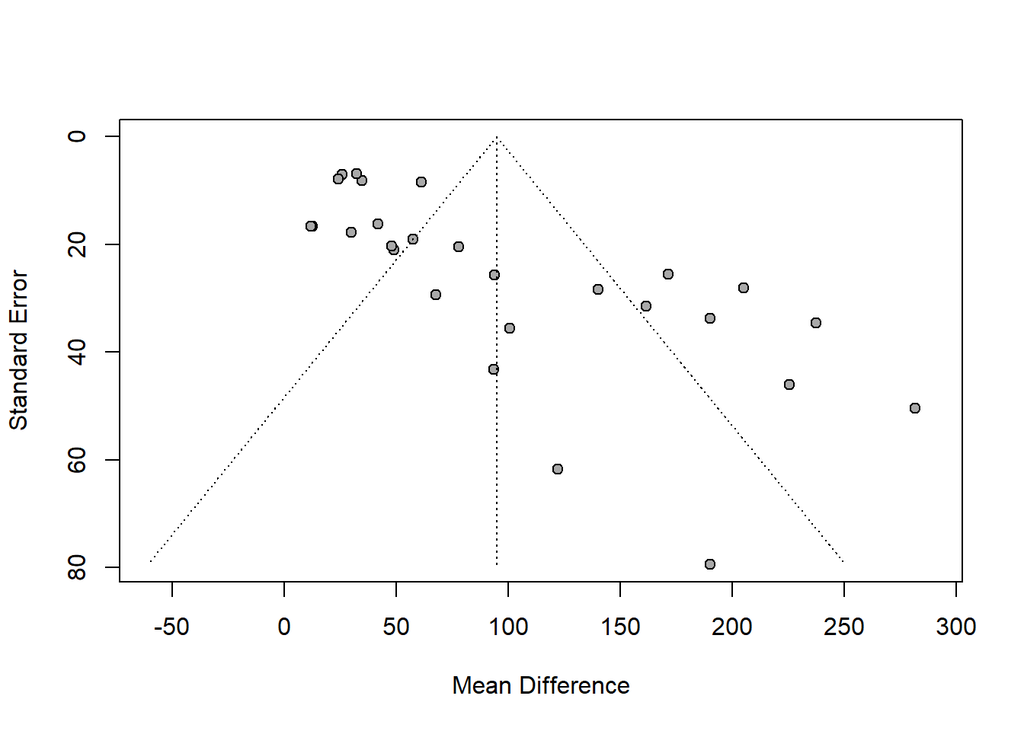

```r
# Plot funnel plot for random effects meta-analysis
random_effect %>% funnel()
```

The above plot shows asymmetry or clustering of data points, it might indicate the presence of publication bias or heterogeneity.

[figure not shown]

```r
# Customize the funnel plot with contour levels and colors
contour_levels <- c(0.70, 0.75, 0.75)
contour_colors <- c("yellow", "green", "red")
funnel(random_effect, contour = contour_levels, col.contour = contour_colors)
legend("topright", c("p < 0.10", "p < 0.05", "p < 0.01"), bty = "n", fill = contour_colors)
```